# prophet_lesson slides

## Facebook Prophet

Prophet is a package from Facebook that contains a suite of tools for analysing and modelling time series data, including:

```
- Ability to recognise daily, weekly, monthly and annual data
- Create models using time series data
- Explore components of model (trend, seasonality etc)
- Perform forecasting and cross validation
- Add regressors (additional features) to model to improve predictive power
```

It is by no means perfect and has its critics, however I believe it is a good starting point for anyone who is new to working with time series data looking to make predictions.

#### Mean hourly footfall for all cameras in Leeds City Centre between 1st January 2015 and 25th April 2021

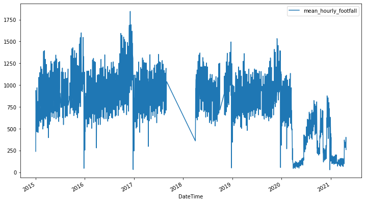

```python
day_for_plot = day.loc[day.index >= '2015-01-01']
dayplot = day_for_plot.plot(figsize=(12,7))
```

Prophet can be used to analyse and make predictions on time series data, taking into account the relationships inherent in this type of data and other elements such as seasonality.

```python
#Prepare expected column names
processed_data = day.reset_index()
processed_data.columns = ['ds','y']

#Create a prelockdown dataset for use in the initial model
prelockdown = processed_data.loc[(processed_data.ds < '2020-03-16') & (processed_data.ds >= '2015-01-01')]

lockdown = processed_data.loc[processed_data.ds >= '2020-03-16'].drop(['y'],axis=1)
```

#### Simple forecast made using training data from between 1st January 2015 and 16th March 2020

```
22:34:55 - cmdstanpy - INFO - Chain [1] start processing
22:34:55 - cmdstanpy - INFO - Chain [1] done processing
```

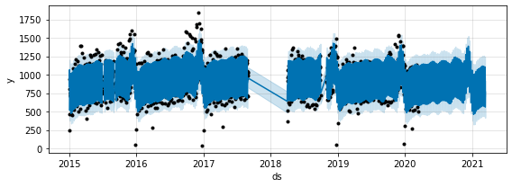

```python
#Define Prophet model
model = Prophet()

#Fit the model
model.fit(prelockdown)

#future is just a dataset that can be used to predict on.  It can be out of sample or represent an in sample test dataset.
future = model.make_future_dataframe(periods=365)

#use the model to make a forecast
forecast = model.predict(future)

#plot the model
plot = model.plot(forecast, figsize=(8,3))
```

#### Annual seasonality of previous model

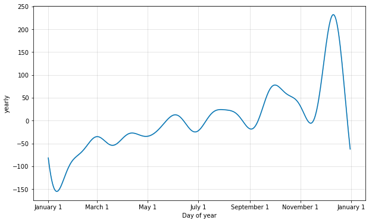

```python
yearly_seasonality = plot_yearly(model)
```

```python
#Evaluation of model.  Training dataset set as everything prior to 1st January 2019,
#test as everything after but prior to the start of lockdown

train = prelockdown.loc[prelockdown.ds <'2019-01-01']
test = prelockdown.loc[prelockdown.ds >='2019-01-01'].drop(['y'],axis=1)
```

#### Chart showing 7 day average of predicted vs true mean hourly footfall

```
MAE: 127.482
```

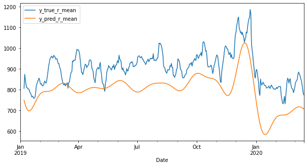

```python
plotdf['y_true_r_mean'] = plotdf['y_true'].rolling(7).mean()
plotdf['y_pred_r_mean'] = plotdf['y_pred'].rolling(7).mean()

plotdf.drop(['y_pred','y_true'],axis=1, inplace=True)

fig = plotdf.plot(figsize=(10,5))
print('MAE: %.3f' % mae)
```

#### Adding regressors to a Prophet Model

```python
#Define Prophet model
model = Prophet()
for r in regressors:
	model.add_regressor(r)
#Fit the model
model.fit(train)
```

```
22:34:59 - cmdstanpy - INFO - Chain [1] start processing
22:34:59 - cmdstanpy - INFO - Chain [1] done processing
```

```
<prophet.forecaster.Prophet at 0x229a4a3e700>
```

The chart below shows the same process outlined earlier, but with the following regressors added to the model:

- Saturday or not?
- Sunday or not?
- Mean daily temperature (degree celsius)
- Mean daily wind speed (MPH)
- Total daily rainfall (mm)
- Bank Holiday or not?
- School Holiday or not?

#### Chart showing 7 day average of predicted vs true mean hourly footfall (with regressors)

```
Mean Average Error: 76.178
```

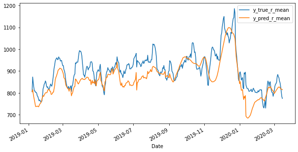

```python
plotdf['y_true_r_mean'] = plotdf['y_true'].rolling(7).mean()
plotdf['y_pred_r_mean'] = plotdf['y_pred'].rolling(7).mean()

plotdf.drop(['y_pred','y_true'],axis=1, inplace=True)


fig = plotdf.plot(figsize=(10,5))
print('Mean Average Error: %.3f' % mae)
```